# MTH6139 Time Series

# Comparing Time Frames

So far the model has been trained on data from 2015 onwards. However, the dataset contains monthly prices going back to 1995, giving us 30 years of history. Here we fit a second Prophet model using the full dataset to see whether the longer history changes our forecast.

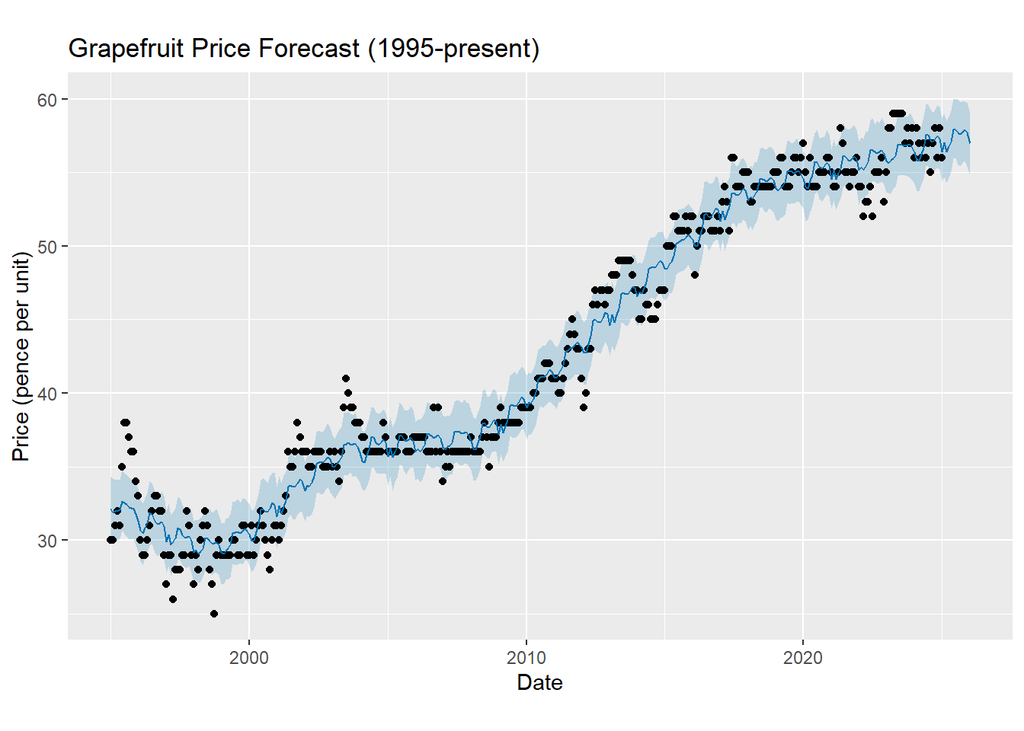

Prophet forecast using full data from 1995

The model trained on the full history produces a noticeably different forecast. Crucially, it captures the long period of stagnation between roughly 2000 and 2010 where prices barely moved. This leads the model to take a more conservative view of long run growth, producing a flatter forecast compared to the 2015 only model.

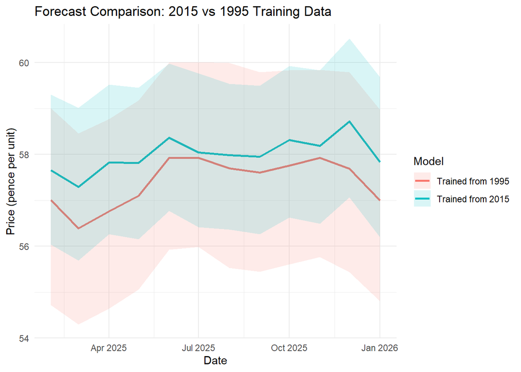

Comparing 12-month forecasts from both models

# Components

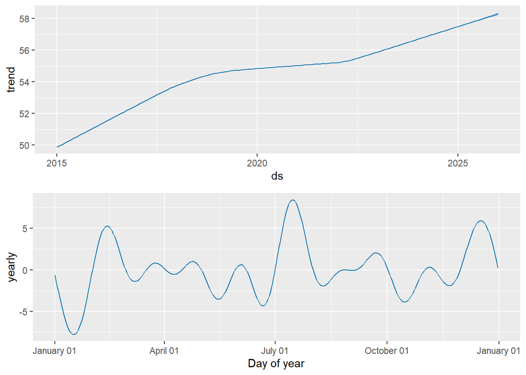

Trend and seasonal components of the Prophet model

# Model Limitations

Prophet assumes that the historical patterns of trend and seasonality will continue into the future at a broadly similar rate. In practice, grapefruit prices are influenced by factors the model cannot observe, such as poor harvests caused by extreme weather, shipping disruptions, currency movements affecting import costs, or sudden changes in consumer demand that could all cause prices to deviate from the forecast. The plateau visible in 2020-2021 is a clear example: this likely reflects COVID-19 disruption to supply chains, which Prophet has no mechanism to anticipate or explain. Two further structural limitations are worth noting. First, Prophet’s default trend model is piecewise linear, which assumes that growth happens in straight-line segments. If grapefruit prices were accelerating, for instance due to sustained inflation, a saturating or logistic growth model might be better suited. Second, the monthly frequency of the data means that within-month price volatility is invisible to the model; for applications requiring finer-grained forecasts, weekly or daily data would be needed. The forecast should therefore be treated as a baseline expectation under broadly normal market conditions, rather than a definitive prediction.

# Model Refinement

To investigate whether model fit could be improved, a log transformation is applied to the price series before fitting. Log transformations are useful when variance grows proportionally with the level of the series as they stabilise fluctuations and tend to produce better-behaved residuals.

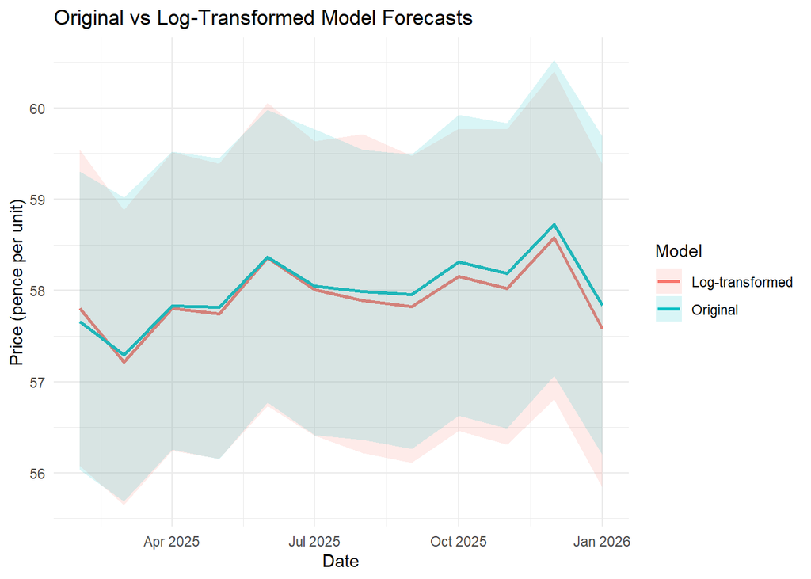

Comparing original and log-transformed model forecasts

# References

Office for National Statistics (2026). *RPI: Average price - Grapefruit, each (pence).* Series ID: DOHN. Dataset: MM23. Released 18 February 2026. Available at: https://www.ons.gov.uk [Accessed: March 2026].